# SemanticDistance

Compute Semantic Relatedness between Constituents of Sequential Continuous Text

[figure not shown]

[figure not shown]

# Overview

`SemanticDistance` executes the following operations:  
1) cleans and formats ordered text (monologues and dialogues)  
2) cleans and formats unordered word lists (e.g., bags-of-words)  
3) computes pairwise semantic distance metrics using numerous chunking options  
4) finds clustering solutions and creates simple semantic networks from given word list vectors.

# Install & Load Package

Install the development version of `SemanticDistance` using the `devtools` package.

```r
#devtools::install_github("Reilly-ConceptsCognitionLab/SemanticDistance")
library(SemanticDistance)
```

# Step 1: Identify Your Data Structure

`SemanticDistance` contains specialized functions for processing the text formats delineated to follow. To learn more about the specific options for string cleaning, computing distances, and visualizing output for each of these formats, visit its corresponding vignette.

## Monologue (example)

| mytext |
| --- |
| The girl walked down the street. The wrestler punched the boxer. I could not open the door. 95 dogs jumped on me. |

A monologue for our purposes consists of any block of text NOT delineated by a talker/speaker. This includes ordered texts like stories or narratives, or unordered lists (i.e., bags of words). The minimum requirement for a monologue is one row and one column with some text in it. Here’s a sample monologue.

## Dialogue (example)

| text | speaker |
| --- | --- |
| Hi Peter. It’s nice to see you | Mary |
| Hi Mary. Hot out today | Peter |
| It sure is. | Mary |
| Did you read that book? | Peter |
| No I haven’t had time. | Mary |

A dialogue is an ordered language sample split by a talker/speaker/interlocutor factor. The minimum requirement for formatting dialogues is to supply a dataframe with two columns. One column is delineated by a speaker_id (e.g., name, speaker, talker) and the second column should contain the speaker’s corresponding text output. Above you will see a sample dialogue formatted correctly for all proceeding steps of `SemanticDistance`.

## Word Pairs in Columns (example)

| word1 | word2 |
| --- | --- |
| Dog | trumpet |
| the | BANANA |
| rat | astronaut |
| *&^% | lizard |
| bird | bird |
| shark | shark |

Word pairs arrayed as vectors within columns. The minimum requirment is two columns with at least one row of paired data (e.g., dog, leash). Here’s a sample dataframe of word pairs formatted correctly for all proceeding steps of `SemanticDistance`.

## Unordered Word List (example)

| mytext |
| --- |
| trumpet trombone flute piano guitar gun knife missile bullet spear apple banana tomato sad angry happy disgusted |

An unordered bag of words. You needn’t split your text but okay if you do. Here’s a sample dataframe. You would use this format for analyzing structure and network properties using dendrogram or network options.

# Step 2 Clean and Format Data

Transforms text to lowercase then optionally clean (omit stopwords, omit non-alphabetic chars), lemmatize (transforms morphological derivatives of words to their standard dictionary entries), and split multiword utterances into a one-word-per row format.

## Clean Monologue or Unordered Word List

## `clean_monologue_or_list`

Arguments to `clean_monologue_or_list`  
-`dat` raw dataframe with at least one column of text.  
-`wordcol` quoted variable column name where your target text lives (e.g., ‘mytext’)  
-`omit_stops` omits stopwords, T/F default is TRUE.  
-`lemmatize` transforms raw word to lemmatized form, T/F default is TRUE.

```r
Monologue_Cleaned <- clean_monologue_or_list(dat=Monologue_Typical, wordcol='mytext', omit_stops=TRUE, lemmatize=TRUE)
knitr::kable(head(Monologue_Cleaned, 12), format = "pipe", digits=2)
```

| id_row_orig | text_initialsplit | word_clean | id_row_postsplit |
| --- | --- | --- | --- |
| 1 | the | NA | 1 |
| 1 | girl | girl | 2 |
| 1 | walked | walk | 3 |
| 1 | down | down | 4 |
| 1 | the | NA | 5 |
| 1 | street. | street | 6 |
| 1 | the | NA | 7 |
| 1 | wrestler | wrestler | 8 |
| 1 | punched | punch | 9 |
| 1 | the | NA | 10 |
| 1 | boxer. | boxer | 11 |
| 1 | i | NA | 12 |

## Clean Dialogue Transcripts

## `clean_dialogue`

```r
Dialogue_Cleaned <- clean_dialogue(dat=Dialogue_Typical, wordcol="text", who_talking = "speaker", omit_stops=TRUE, lemmatize=TRUE)
knitr::kable(head(Dialogue_Cleaned, 12), format = "pipe", digits=2)
```

| id_row_orig | text_initialsplit | speaker | word_clean | id_row_postsplit | turn_count |
| --- | --- | --- | --- | --- | --- |
| 1 | hi | Mary | NA | 1 | 1 |
| 1 | peter | Mary | peter | 2 | 1 |
| 1 | its | Mary | NA | 3 | 1 |
| 1 | its | Mary | NA | 4 | 1 |
| 1 | nice | Mary | nice | 5 | 1 |
| 1 | to | Mary | NA | 6 | 1 |
| 1 | see | Mary | see | 7 | 1 |
| 1 | you | Mary | NA | 8 | 1 |
| 2 | hi | Peter | NA | 9 | 2 |
| 2 | mary | Peter | mary | 10 | 2 |
| 2 | hot | Peter | hot | 11 | 2 |
| 2 | out | Peter | out | 12 | 2 |

## Clean/Format Word Pairs in Columns

## `clean_paired_cols`

Your data for computing pairwise semantic distance are arrayed in two paired columns in a dataframe. These columns need not be adjacent. You will specify their variable names in the function call.

```r
WordPairs_Clean <- clean_paired_cols(dat=Word_Pairs, wordcol1='word1', wordcol2='word2', lemmatize=TRUE)
knitr::kable(head(WordPairs_Clean, 6), format = "simple", digits=2)
```

| id_row_orig | word1_clean | word2_clean | word1 | word2 |
| --- | --- | --- | --- | --- |
| 1 | dog | trumpet | Dog | trumpet |
| 2 | the | banana | the | BANANA |
| 3 | rat | astronaut | rat | astronaut |
| 5 | bird | bird | bird | bird |
| 6 | shark | shark | shark | shark |
| 8 | dog | leash | Dog | leash |

# Step 3: Compute Semantic Distance

Now compute semantic distance for your selected format from one of the options below.

## Ngram-to-Word Distance

## `dist_ngram2word`

This function works on monologues (continuous ordered samples) only! Computes cosine distance using a rolling ngram approach consisting of groups of words (ngrams) to the next word. *IMPORTANT* the function looks backward from the target word skipping over NAs until filling the desired ngram size.

Arguments to `dist_ngram2word`:  
-`dat` dataframe of a monologue transcript cleaned and prepped.  
-`ngram` window size preceding each new content word.

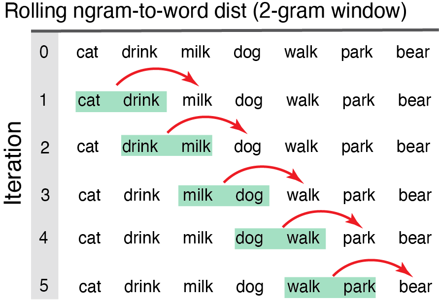

rolling groupings of words

```r
Ngram2Word_Dists1 <- dist_ngram2word(dat=Monologue_Cleaned, ngram=1) #distance word-to-word
knitr::kable(head(Ngram2Word_Dists1, 8), format = "pipe", digits = 2)
```

| id_row_orig | text_initialsplit | word_clean | id_row_postsplit | CosDist_1gram_glo | CosDist_1gram_sd15 |
| --- | --- | --- | --- | --- | --- |
| 1 | the | NA | 1 | NA | NA |
| 1 | girl | girl | 2 | NA | NA |
| 1 | walked | walk | 3 | 0.47 | 1.06 |
| 1 | down | down | 4 | 0.28 | 0.80 |
| 1 | the | NA | 5 | NA | NA |
| 1 | street. | street | 6 | 0.36 | 0.87 |
| 1 | the | NA | 7 | NA | NA |
| 1 | wrestler | wrestler | 8 | 0.97 | 0.63 |

## Ngram-to-Ngram Distance

## `dist_ngram2ngram`

This function works on monologues (continuous ordered samples) only. User specifies n-gram size (e.g., ngram=2). Distance computed from each two-word chunk to the next iterating all the way down the dataframe until there are no more words to ‘fill out’ the last ngram.

Arguments to `dist_ngram2ngram`  
-`dat` dataframe w/ a monologue sample cleaned and prepped  
-`ngram` chunk size (chunk-to-chunk), (e.g., ngram=2 means chunks of 2 words compared to the next chunk of two words).

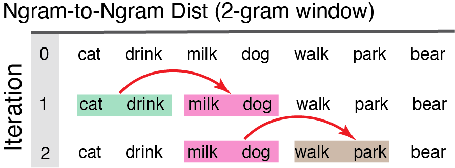

chunk-to-chunk groupings of words

```r
Ngram2Ngram_Dist1 <- dist_ngram2ngram(dat=Monologue_Cleaned, ngram=2)
knitr::kable(head(Ngram2Ngram_Dist1, 8), format = "pipe", digits = 2)
```

| id_row_orig | text_initialsplit | word_clean | id_row_postsplit | CosDist_2gram_GLO | CosDist_2gram_SD15 |
| --- | --- | --- | --- | --- | --- |
| 1 | the | NA | 1 | NA | NA |
| 1 | girl | girl | 2 | NA | NA |
| 1 | walked | walk | 3 | NA | NA |
| 1 | down | down | 4 | 0.14 | 1.05 |
| 1 | the | NA | 5 | 0.06 | 0.09 |
| 1 | street. | street | 6 | 0.32 | 0.94 |
| 1 | the | NA | 7 | 0.32 | 0.94 |
| 1 | wrestler | wrestler | 8 | 0.93 | 1.18 |

## Anchor-to-Word Distance

## `dist_anchor`

This function works on monologues (continuous ordered samples) only! Models semantic distance from each successive new word to the average of the semantic vectors for the first block of N content words. This anchored distance provides a metric of overall semantic drift as a language sample unfolds relative to a fixed starting point.

Arguments to `dist_anchor`  
-`dat` dataframe monologue sample cleaned and prepped using `clean_monologue`.  
-`anchor_size` size of the initial chunk of words for chunk-to-new-word comparisons.

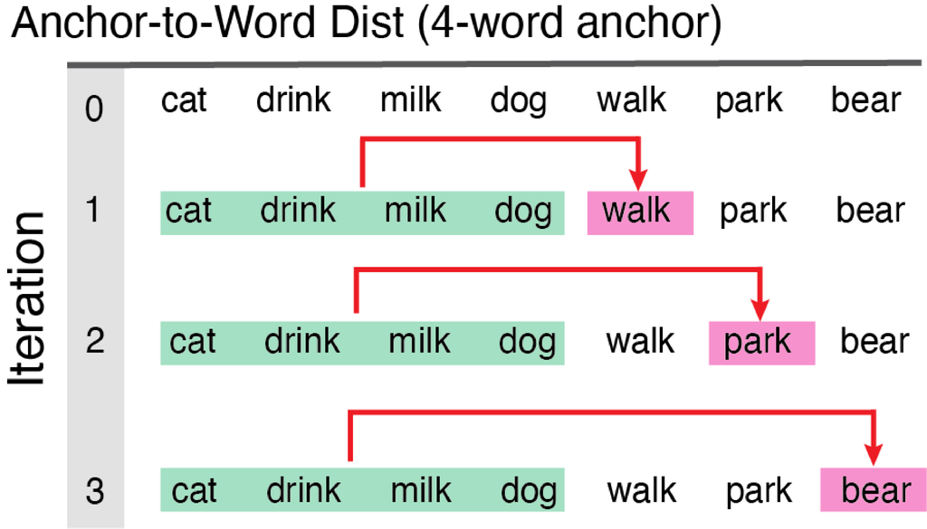

fixed initial chunk of words to each new word or ngram

```r
Anchored_Dists1 <- dist_anchor(dat=Monologue_Cleaned, anchor_size=8)
knitr::kable(head(Anchored_Dists1, 4), format = "pipe", digits = 2)
```

| id_row_postsplit | word_clean | CosDist_Anchor_GLO | CosDist_Anchor_SD15 |
| --- | --- | --- | --- |
| 1 | NA | NA | NA |
| 2 | girl | 0.26 | 0.42 |
| 3 | walk | 0.16 | 0.19 |
| 4 | down | 0.12 | 0.27 |

## Turn-to-Turn Distance

## `dist_dialogue`

This function works on dialogue transcripts only!!! Averages semantic vectors for all content words in each speaker’s turn then computes the cosine distance to the average of the semantic vectors of the content words in the subsequent turn.

Arguments to `dist_dialogue`:  
-`dat` dataframe w/ a dialogue sample cleaned and prepped using `clean_dialogue`.  
-`who_talking` quoted argument specifying 2-level factor variable name for person producing given text.

```r
DialogueDists <- dist_dialogue(dat=Dialogue_Cleaned, who_talking='speaker')
knitr::kable(head(DialogueDists, 4), format = "pipe", digits = 2)
```

| turn_count | speaker | n_words | glo_cosdist | sd15_cosdist |
| --- | --- | --- | --- | --- |
| 1 | Mary | 3 | 0.83 | 0.58 |
| 2 | Peter | 4 | 0.85 | 0.58 |
| 3 | Mary | 1 | 0.86 | 0.58 |
| 4 | Peter | 3 | 0.86 | 0.45 |

## Word Pair Distance

## `dist_paired_cols`

This function works on word pairs in columns only!!! Output of `dist_paired_cols` on 2-column arrayed dataframe.

Arguments to `dist_paired_cols`  
-`dat` dataframe w/ word pairs arrayed in columns cleaned and prepped.

```r
Columns_Dists <- dist_paired_cols(WordPairs_Clean) #only argument is dataframe
knitr::kable(head(Columns_Dists, 6), format = "pipe", digits = 2)
```

| id_row_orig | word1_clean | word2_clean | word1 | word2 | CosDist_SD15 | CosDist_GLO |
| --- | --- | --- | --- | --- | --- | --- |
| 1 | dog | trumpet | Dog | trumpet | 0.45 | 0.84 |
| 2 | the | banana | the | BANANA | 1.18 | 0.77 |
| 3 | rat | astronaut | rat | astronaut | 1.22 | 0.93 |
| 5 | bird | bird | bird | bird | 0.00 | 0.00 |
| 6 | shark | shark | shark | shark | 0.00 | 0.00 |
| 8 | dog | leash | Dog | leash | 0.68 | 0.50 |

# Data Visualization Options for Semantic Networks

Choose your visualization option based on the nature of your data. An temporally ordered text such as a story can be plotted like a time series. This would not make sense for Unordered lists (bags-of-words). However, with word lists you might be interested in using scaling procedures to find latent structure or similarities. `SemanticDistance` has two options for computing clustering and network properties for a vector of words, i.e., hierarchical clustering and simple network visualization. The function also returns a square matrix with all pairwise semantic distance values for a word list.

## Hierarchical Cluster Dendrogram

## `wordlist_to_network`

Produces a dendogram from a vector of words. First pulls words, then creates a square matrix with cosine distances for all possible word pairs: d[i,j]. Then converts semantic distance matrix to Euclidean distance. Then plots a hierchcial clustering solution moving words closer together in proximity based on their distance. Works best for unordered word lists.

Arguments to `wordlist_to_network`:  
-`dat` dataframe processed using `clean_monologue_or_list()`  
-`output` quoted argument `dendrogram` or `network` default is `dendrogram`.  
-`dist_type` quoted argument, which distance norms would you like? default is `embedding` alternative is `SD15`.

```
#> [1] "Length of words: 17"
#> [1] "my_kmax: 10"
```

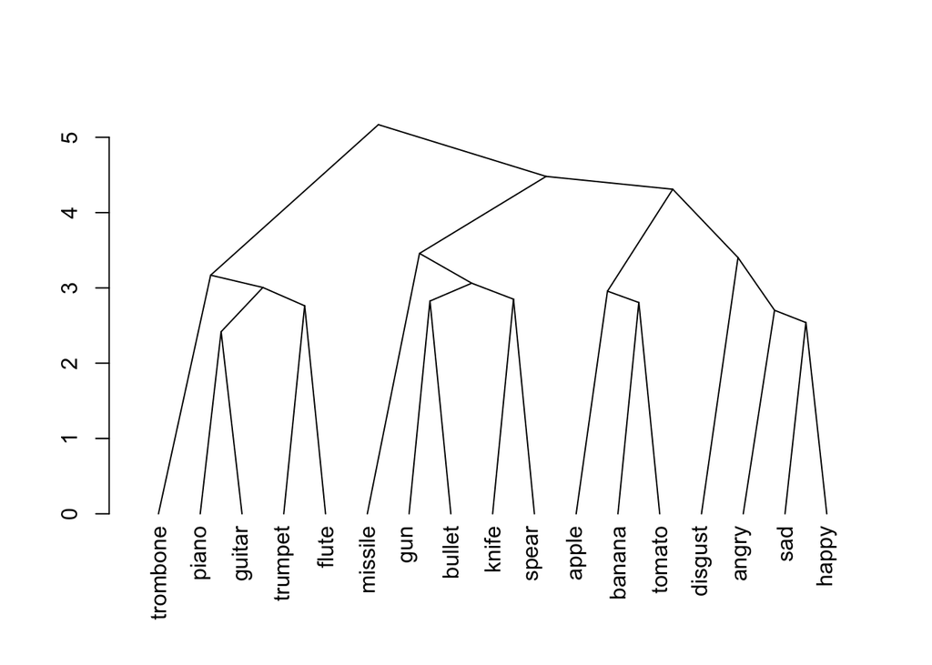

```r
MyCleanList <- clean_monologue_or_list(dat=Unordered_List, wordcol='mytext')
mydendro <- wordlist_to_network(MyCleanList, output='dendrogram', dist_type='embedding')
```

```r
print(mydendro)
```

```
#> 'dendrogram' with 2 branches and 17 members total, at height 5.168642
```

## iGraph network (graph plot)

```r
MyCleanList <- clean_monologue_or_list(dat=Unordered_List, wordcol='mytext')
mynetwork <- wordlist_to_network(MyCleanList, output='network', dist_type='embedding')
```

```
#> [1] "Length of words: 17"
#> [1] "my_kmax: 10"
```

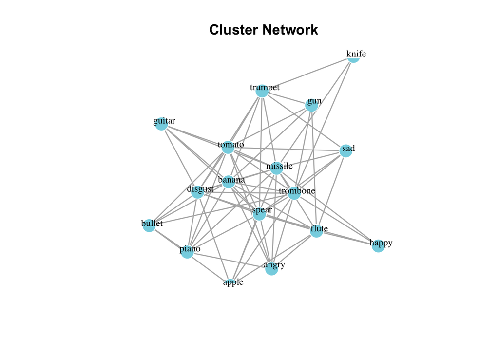

```r
print(mynetwork)
```

```
#> IGRAPH 130535d UNW- 17 68 --
#> + attr: name (v/c), cluster (v/n), color (v/c), size (v/n), label
#> | (v/c), label.color (v/c), label.cex (v/n), weight (e/n), color (e/c),
#> | width (e/n)
#> + edges from 130535d (vertex names):
#>  [1] trombone--missile trombone--gun     trombone--bullet  trombone--knife
#>  [5] trombone--spear   trombone--apple   trombone--banana  trombone--tomato
#>  [9] trombone--disgust trombone--angry   trombone--sad     trombone--happy
#> [13] piano   --missile piano   --bullet  piano   --spear   piano   --banana
#> [17] piano   --tomato  piano   --disgust piano   --angry   guitar  --missile
#> [21] guitar  --spear   guitar  --banana  guitar  --tomato  guitar  --disgust
#> + ... omitted several edges
```

# Getting Help

For bugs, feature requests, and general questions, reach out via one of the following options:  
1. [Report Bugs](https://github.com/Reilly-ConceptsCognitionLab/SemanticDistance/issues)  
2. [View Discussions](https://github.com/Reilly-ConceptsCognitionLab/SemanticDistance/discussions)  
3. [Read News and Release Notes](https://github.com/Reilly-ConceptsCognitionLab/SemanticDistance/blob/main/NEWS.md).

If none of these options do the trick, please email the package maintainer, Jamie Reilly for assistance.